# Data Visualization: Group 1

Ana Bento & Reni Kaul

August 18-19 2017

Yesterday we started to explore data visualization in base `R`. Today we will spend time exploring different visualizations using the `ggplot2` package. The different approaches each have their advantages, so you will likely use both during your research career.

# Problem 1

Yesterday we explored the `nycflights13` dataset. One plot was a boxplot of the temperature by month using base `R`. The plot looked like this:

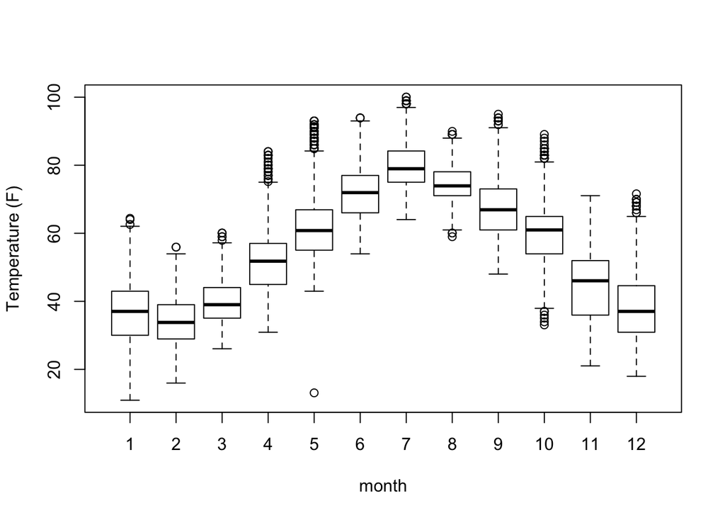

```r
library(nycflights13) #load data from package

boxplot(weather$temp ~ weather$month, xlab="month", ylab="Temperature (F)" ) #instead of assigning x and y values, you can use the syntax y ~ x
```

Today, your goal is to recreate this figure using the `ggplot2` package. `ggplot2` was first published to CRAN in 2005, so a quick google search will return *MANY* tutorials, discussion pages, etc. The general syntax for boxplots in `ggplot2` is:

```r
ggplot(data, #matrix
       aes(x= X.col, y= Y.col)) + #x and y columns in matrix to plot
      geom_boxplot() #plot the data as a box plot
```

A basic `ggplot2` boxplot should look like this:

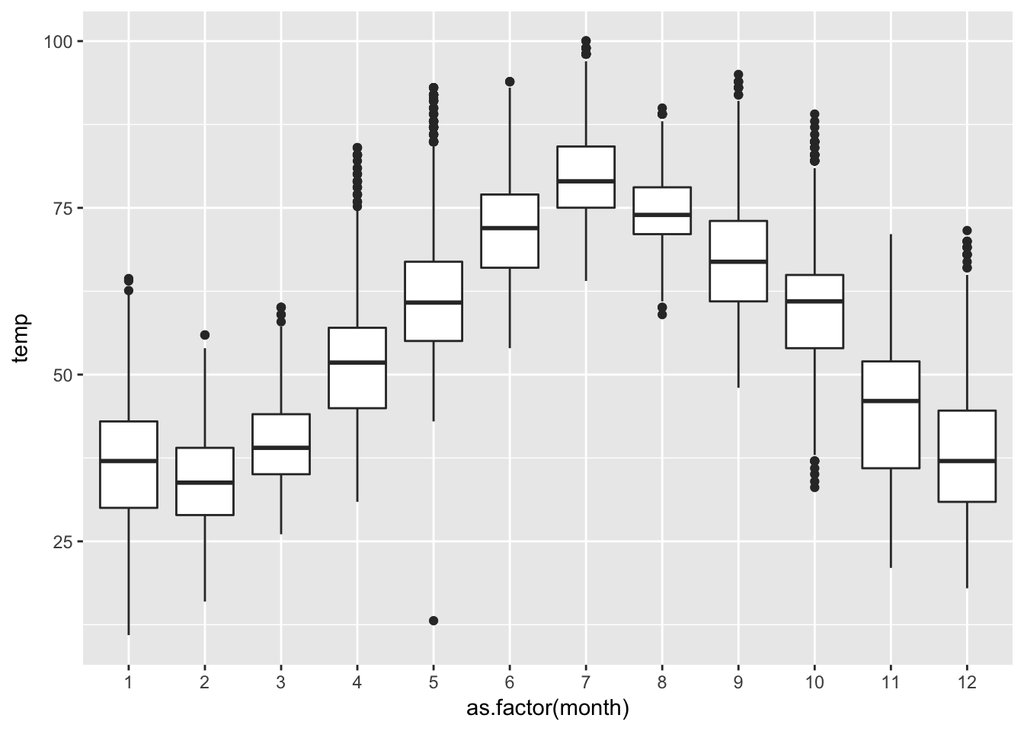

With additional customization, we can produce a plot with a little more shine. For example, this plot has transparent colored boxes and month names instead of numbers.

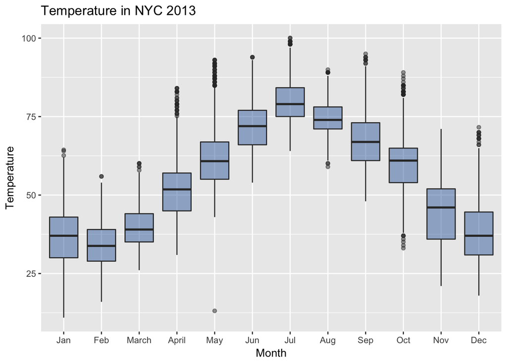

Work with your team to create a polished `ggplot2` boxplot. It doesn’t need to look like these figures, but you are welcome to use them as a guide. A very detailed tutorial is on [ZevRoss](http://zevross.com/blog/2014/08/04/beautiful-plotting-in-r-a-ggplot2-cheatsheet-3/). A more formal guide is in the [R for Data Science](http://r4ds.had.co.nz/data-visualisation.html) visualization chapter.

# Problem 2

For this exercise, we will use `mtcars` in the `datasets` package. Install (if needed) and load the `datasets` package. Explore the `mtcars` dataset which is from the 1974 *Motor Trend US* magazine, and comprises fuel consumption, engine metrics, etc. for 32 car models.

So far we have only created visualizations with 2 dimensions. We can add a third dimension to the data by coloring the plotted points. We can make a basic scatterplot of `mtcars` using `ggplot2`. Here the x-axis is car weight, y-axis mile per gallon, and color is the number of engine cylinders.

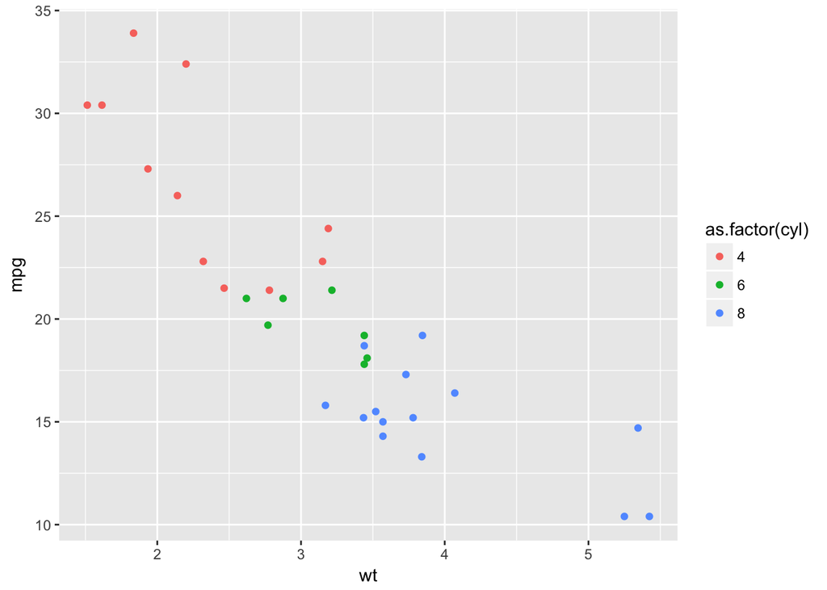

Your goal is to create this figure, and modify it in at least 2 ways. The syntax for a scatterplot is similar to a boxplot but `geom_point()` is used in place of `geom_boxplot()`.